# Google data report #1

Ido Klein

16/11/2021

## google data report

```r
paths <- fs::dir_info("D:/OneDrive_2021_11_10/Google_data_2015_2020/Original_data/access_files2/") %>%
  pull(path) %>%
  as.character()
dbnames <- paths %>% str_split("/") %>% map_chr(~.x[[length(.x)]]) %>% str_sub(end = -7)
df_db = data.frame(dbname = dbnames, path = paths) %>%
  filter(!str_detect(dbname,"\\."))
cons <- map(df_db$path,~odbcDriverConnect(paste0("Driver={Microsoft Access Driver (*.mdb, *.accdb)};DBQ=",.x)))

# creation of googletimes files - ran only once, computer has only 16 giga ram

# googletimes <- map(cons,~sqlQuery(.x, "select * from googletimes"))
# googletimes_table1 <- map2(googletimes,dbnames,~.x %>% mutate(dbname = .y))
# googletimes_table <- googletimes_table1[googletimes_table1 %>% map(~nrow(.x)!=0) %>% as.logical()] %>%
# bind_rows()
# nr <- nrow(googletimes_table)
# map(0:61,~googletimes_table[(1 + .x*1000000):min(1000000 + .x*1000000,nr),] %>%
# write_csv(paste0("google_times",.x,".csv")))

# unifying of googletimes files - ran only once
# googletimes_table <- googletimes %>% bind_rows()
# lst <- dir_info() %>%
#   filter(str_detect(path,".csv")) %>%
#   pull(path) %>%
#   as.character() %>%
#   map(read_csv)
# googletimes_table <- lst %>%
#   bind_rows()
# rm(lst)
# gc()
# write_csv(googletimes_table,"googletimes.csv")
# almost 5 giga, much less than before (around 12)
# saved google data
googletimes<- read_csv("D:/OneDrive_2021_11_10/google_data_anal/googletimes.csv")
# add relevant columns
googletimes$date <- as_date(googletimes$timestamp)
googletimes$from_epoch <- as.numeric(googletimes$timestamp)
# change relevant columns
googletimes$project <-  as.factor(googletimes$project)
googletimes$dbname <-  as.factor(googletimes$dbname)
# gc()
```

I have recieved 30 access database files in the size of ~14 gb.  
one of the files (backup of uptodateprojects,~2gb) was corrupted and could not be processed. Jordan Katz will resend it. the first assignment was converting the actual google data (stord in each db under the “googletimes” table) to one file. the unification of all files created a ~61 million rows file.  
data structure:

```r
head(googletimes)
```

```
## # A tibble: 6 x 10
##      ID  time length maslulid timestamp           sugyom project   dbname
##   <dbl> <dbl>  <dbl>    <dbl> <dttm>               <dbl> <fct>     <fct>
## 1     1   536   7517        1 2017-03-16 11:01:13      1 beinironi allnew_lines
## 2     2   895  18563        2 2017-03-16 11:01:14      1 beinironi allnew_lines
## 3     3   167   4367        3 2017-03-16 11:01:15      1 beinironi allnew_lines
## 4     4   655  19262        4 2017-03-16 11:01:15      1 beinironi allnew_lines
## 5     5   282   8074        5 2017-03-16 11:01:16      1 beinironi allnew_lines
## 6     6    70   1834        6 2017-03-16 11:01:17      1 beinironi allnew_lines
## # ... with 2 more variables: date <date>, from_epoch <dbl>
```

number of rows:

```r
nrow(googletimes)
```

```
## [1] 61036133
```

When trying to find a unique identifier for each row, I found that the ID column is useless

```r
googletimes %>%
  filter(project == "beinironi",ID == 1)
```

```
## # A tibble: 12 x 10
##       ID  time length maslulid timestamp           sugyom project   dbname
##    <dbl> <dbl>  <dbl>    <dbl> <dttm>               <dbl> <fct>     <fct>
##  1     1   536   7517        1 2017-03-16 11:01:13      1 beinironi allnew_lines
##  2     1   399   4909        1 2016-11-13 13:06:46      1 beinironi allnew_line~
##  3     1   255   4909        1 2016-06-26 09:54:04      1 beinironi allprojects
##  4     1   255   4909        1 2016-06-26 09:54:04      1 beinironi allprojects1
##  5     1   255   4909        1 2016-06-26 09:54:04      1 beinironi allprojects~
##  6     1   255   4909        1 2016-06-26 09:54:04      1 beinironi allprojects~
##  7     1   399   4909        1 2016-11-13 13:06:46      1 beinironi all_lines_p~
##  8     1   399   4909        1 2016-11-13 13:06:46      1 beinironi all_lines_p~
##  9     1   404   4909        1 2016-11-13 13:02:50      1 beinironi uptodatepro~
## 10     1   255   4909        1 2016-06-26 09:54:04      1 beinironi uptodatepro~
## 11     1   255   4909        1 2016-06-26 09:54:04      1 beinironi uptodatepro~
## 12     1   469   7517        1 2017-05-14 05:49:22      1 beinironi גל תכנון עי~
## # ... with 2 more variables: date <date>, from_epoch <dbl>
```

and that some of the projects are spread around multiple dbs

```r
googletimes %>%
  filter(project == "beinironi") %>%
  count(dbname) %>%
  arrange(-n)
```

```
## # A tibble: 14 x 2
##    dbname                                   n
##    <fct>                                <int>
##  1 allnew_lines                       5543467
##  2 new_OD_line                        2149959
##  3 uptodateprojects                   1790965
##  4 all_lines_projects                 1549222
##  5 allnew_lines_Backup                1386681
##  6 uptodateprojects_Backup            1325896
##  7 allprojects1                        784465
##  8 allprojects1_Backup                 363685
##  9 allprojects                         342836
## 10 allprojects_Backup                  121742
## 11 all_lines_OD_Backup                  94330
## 12 all_lines_projects_Backup             4374
## 13 גל תכנון עירוני_Backup                 400
## 14 uptodateprojects - template_Backup      20
```

therefore I made each row distinct by using all of its values, besides the dbname and id

```r
distincts <- googletimes %>%
  select(-ID,-dbname) %>%
  distinct()
```

```r
largest_proj2 <- distincts %>%
  count(project) %>%
  arrange(-n)
largest_proj2
```

```
## # A tibble: 232 x 2
##    project                                n
##    <fct>                              <int>
##  1 beinironi                       11128387
##  2 נתצים עירוני- מחולק לשתיים       6682625
##  3 נעים לירוק 3                     3440038
##  4 NA                               3179964
##  5 מנתניה לאשדוד                    2429980
##  6 אשדוד                            1379826
##  7 נתצים בין עירוניים - 23-03-2016  1092536
##  8 צוואר הבקבוק- מתוקן               849980
##  9 צמתים בנגב- חדש                   736378
## 10 יחידת מודלים תא                   702452
## # ... with 222 more rows
```

time coverage of 10 largest projects is missing april 2018 to may 2019. this data exists, I have saved some of it about two years ago - mainly the beinironi, however it does not appear in matat files

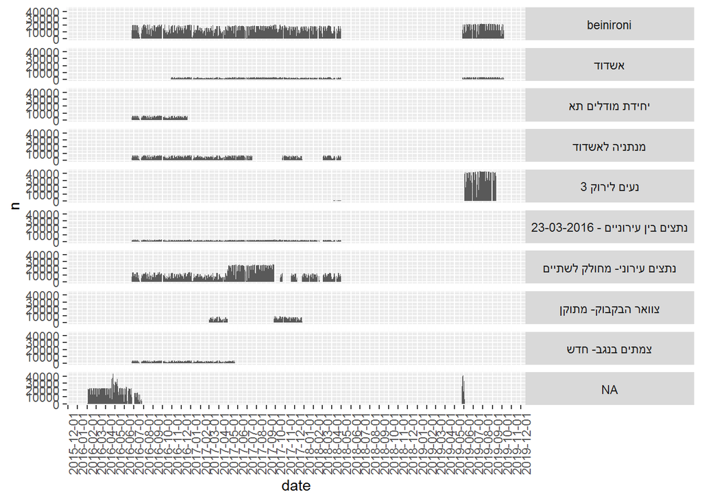

```r
distincts %>%
  filter(project %in% largest_proj2$project[1:10]) %>%
  count(project,date) %>%
  arrange(-n) %>%
  ggplot(aes(x=date,y=n)) +
  geom_col() +
  facet_grid(project~.) +
  theme(strip.text.y = element_text(angle = 0),
        axis.text.x = element_text(angle = 90)) +
  scale_x_date(date_breaks = "1 month")
```

regarding other tables - very big mess. some of the dbs have certain tables, other dont. the kind we are interested in is the meta data for the project and maslulid

```r
table_status <- map(cons,~sqlTables(.x, tableType = "TABLE")) %>%
  bind_rows() %>%
  left_join(df_db, by = c("TABLE_CAT" = "path")) %>%
  select(dbname,TABLE_NAME) %>%
  mutate(num = 1) %>%
  spread(TABLE_NAME,num)
table_status
```

```
##                                dbname calendar googletimes maslulim
## 1                 all_lines_OD_Backup        1           1       NA
## 2                  all_lines_projects        1           1       NA
## 3           all_lines_projects_Backup        1           1       NA
## 4                        allnew_lines        1           1       NA
## 5                 allnew_lines_Backup        1           1       NA
## 6                         allprojects        1           1       NA
## 7                  allprojects_Backup        1           1       NA
## 8                        allprojects1        1           1       NA
## 9                 allprojects1_Backup        1           1       NA
## 10                          beinironi        1           1        1
## 11               matrix all projeccts       NA           1       NA
## 12        matrix all projeccts_Backup       NA           1       NA
## 13                   Nayim_le_yarok_3       NA           1       NA
## 14                        new_OD_line        1           1       NA
```

[output cut: 75 more lines]

when calculating this, I have only 110 unique projects, as opposed to 232 existing in the google times table. that means that for more than a hundred project, a simple join of each maslul can not be carried out. the number of maslulim per project is presented in this table.

```r
# get all calemders, see whether there are problems
calendar <- map(cons,~sqlQuery(.x, "select * from calendar"))
has_calendar <- map(calendar,~class(.x) =="data.frame") %>% unlist()
calendar_table1 <- map2(calendar[has_calendar],df_db$dbname[has_calendar],function(x,y){x %>% mutate(dbname = y)})
calendar_table <- calendar_table1[calendar_table1 %>% map(~nrow(.x)!=0) %>% as.logical()] %>%
  bind_rows()
gc()
```

```
##              used   (Mb) gc trigger    (Mb)   max used    (Mb)
## Ncells    1274131   68.1    2281634   121.9    2281634   121.9
## Vcells 1024496715 7816.3 1562868352 11923.8 1403937425 10711.2
```

```r
# got a distinct calender. only for 2016-2017
dis_calender <- calendar_table %>%
  select(-dbname) %>%
  distinct()
# get all newroutes see whether there are problems
newroutes <- map(cons,~sqlQuery(.x, "select * from newroutes"))
has_newroutes <- map(newroutes,~class(.x) =="data.frame") %>% unlist()
newroutes_table1 <- map2(newroutes[has_newroutes],df_db$dbname[has_newroutes],function(x,y){x %>% mutate(dbname = y)})
# map(newroutes_table1,~.x$מסלול %>% class())
newroutes_table1[[26]]$מסלול <- as.character(newroutes_table1[[26]]$מסלול)
newroutes_table <- newroutes_table1[newroutes_table1 %>% map(~nrow(.x)!=0) %>% as.logical()] %>%
  bind_rows()
# got distinct newroutes, however they are lacking, most likely to be found in "maslulim"
dis_newroutes <- newroutes_table %>%
  select(-dbname) %>%
  distinct()

# testrips - like googletimes, however meant to test the db
testrips  <- map(cons,~sqlQuery(.x, "select * from testrips"))
has_testrips<- map(testrips,~class(.x) =="data.frame") %>% unlist()
testrips_table1 <- map2(testrips[has_testrips],df_db$dbname[has_testrips],function(x,y){x %>% mutate(dbname = y)})

testrips_table <- testrips_table1[testrips_table1 %>% map(~nrow(.x)!=0) %>% as.logical()] %>%
  bind_rows()
# got distinct testrips, don't know what to do with them
dis_testrips  <- testrips_table %>%
  select(-dbname) %>%
  distinct()

# trips - like newroutes
trips  <- map(cons,~sqlQuery(.x, "select * from trips"))
has_trips <- map(trips,~class(.x) =="data.frame") %>% unlist()
trips_table1 <- map2(trips[has_trips],df_db$dbname[has_trips],function(x,y){x %>% mutate(dbname = y)})
# map(trips_table1,~.x$מסלול %>% class())
trips_table1[[22]]$מסלול <- as.character(trips_table1[[22]]$מסלול)
trips_table <- trips_table1[trips_table1 %>% map(~nrow(.x)!=0) %>% as.logical()] %>%
  bind_rows()
# got distinct trips, they are like newroutes. however, querying a matrix is differnt than a simple api call, need to split
dis_trips <- trips_table %>%
  select(-dbname) %>%
  distinct()
not_all_na <- function(x) any(!is.na(x))
matrices <- dis_trips %>%
  filter(!is.na(project)) %>%
  select_if(not_all_na)
dis_trips_not_matrices <- dis_trips %>%
  filter(is.na(project)) %>%
  select_if(not_all_na)


# trips_all - like newroutes
trips_all <- map(cons,~sqlQuery(.x, "select * from trips_all"))
has_trips_all <- map(trips_all,~class(.x) =="data.frame") %>% unlist()
trips_all_table1 <- map2(trips_all[has_trips_all],df_db$dbname[has_trips_all],function(x,y){x %>% mutate(dbname = y)})

# map(trips_all_table1,~.x$מסלול %>% class())
trips_all_table1[[26]]$מסלול <- as.character(trips_all_table1[[26]]$מסלול)
trips_all_table <- trips_all_table1[trips_all_table1 %>% map(~nrow(.x)!=0) %>% as.logical()] %>%
  bind_rows()
# got distinct trips, they are like newroutes. however, querying a matrix is differnt than a simple api call, need to split
dis_trips_all <- trips_all_table %>%
  select(-dbname) %>%
  distinct()


# explore trips1, wait and waiting times
trips1 <- map(cons,~sqlQuery(.x, "select * from trips1"))
has_trips1 <- map(trips1,~class(.x) =="data.frame") %>% unlist()
trips1_table1 <- map2(trips1[has_trips1],df_db$dbname[has_trips1],function(x,y){x %>% mutate(dbname = y)})
trips1_table <- trips1_table1[trips1_table1 %>% map(~nrow(.x)!=0) %>% as.logical()] %>%
  bind_rows()
dis_trips1 <- trips1_table %>%
  select(-dbname) %>%
  distinct()
# have only 110 projects, out of 232 with data. concerning

meta_data_proj <- bind_rows(dis_trips_not_matrices,dis_newroutes,dis_trips_all,dis_trips1) %>%
  select_if(not_all_na) %>%
  select(`פרוייקט`,maslulid) %>%
  distinct() %>%
  count(`פרוייקט`) %>%
  arrange(-n)
meta_data_proj
```

```
##                                פרוייקט    n
## 1                         נעים לירוק 3 5950
## 2                    מועצות מוניצפליות 1028
## 3           נתצים עירוני- מחולק לשתיים  527
## 4                            beinironi  400
## 5       נתיבי איילון 200 מטר לצפון חדש  228
## 6                  צוואר הבקבוק- מתוקן  179
## 7       נתיבי איילון 200 מטר לדרום חדש  156
## 8                        מנתניה לאשדוד  150
## 9                          חיפה מנהרות  126
## 10                הרשות לבטיחות בדרכים  123
## 11                     יחידת מודלים תא  123
## 12                           גל עירוני  120
## 13                  מערך חילוץ ירושלים  120
## 14                  תוספות לבין עירוני  116
```

[output cut: 96 more lines]

projects that can be joined:

```r
largest_proj2 %>%
  filter(project %in% meta_data_proj$פרוייקט)
```

```
## # A tibble: 104 x 2
##    project                                n
##    <fct>                              <int>
##  1 beinironi                       11128387
##  2 נתצים עירוני- מחולק לשתיים       6682625
##  3 נעים לירוק 3                     3440038
##  4 NA                               3179964
##  5 מנתניה לאשדוד                    2429980
##  6 אשדוד                            1379826
##  7 נתצים בין עירוניים - 23-03-2016  1092536
##  8 צוואר הבקבוק- מתוקן               849980
##  9 צמתים בנגב- חדש                   736378
## 10 יחידת מודלים תא                   702452
## # ... with 94 more rows
```

projects that can’t be joined:

```r
largest_proj2 %>%
  filter(!project %in% meta_data_proj$פרוייקט)
```

```
## # A tibble: 128 x 2
##    project                      n
##    <fct>                    <int>
##  1 צוואר בקבוק 2           330278
##  2 שדות תעופה              227865
##  3 סל גודש- צמתים          213508
##  4 כביש 446- צוואר בקבוק   206341
##  5 בת ים                   205183
##  6 בני ברק                 202103
##  7 עכו                     139966
##  8 משלימה אסטרטגית- מקטעים 130680
##  9 הרצליה                  129646
## 10 כביש 2 לצפון- 200 מטר   116495
## # ... with 118 more rows
```

next assignments:  
1. find missing metadata regarding maslulim  
2. talk to matat regarding missing year  
3. create geometric features for each maslul  
4. store all relevant data in a gpkg (geographic local database serving as one package)  
5. document the tables and rows  
6. perform data quality assurance (if I remember correctly, there might be a 2 hour lag)  
7. prepare for distribution  
8. talk to lishcah mishpatit regarding distribution